The data are one year of sales data for a a large number of grocery stores for products in the paper towel category. There are three data files:

- **sales.rds**: Each row is data on sales for a (store,week,product) combination. For more information see the salesINFO.txt file.
- **products.rds**: Each row is information on one product (UPC = Universal Product Code. This is a unique bar code for each product). For more information see the productINFO.txt file.
- **stores.rds**: Each row is information on one store. For more information see the storesINFO.txt file. Note that you have information of when each store opened (and whether or not it closed during the 52 week period). Note also that some stores close and then reopen later under a different store chain name. Due to this phenomenon there are more rows in the store file than there are stores (i.e., some stores occur twice).

Manufacturers and grocery store managers use data like this to understand preferences for different types of product in category, how these preferences vary over time and location, and how sales can be impacted by marketing strategies such as price promotions.

First look at total sales in dollars for all stores combined. Which week (report the week index WEEK) had the highest sales in dollars and what was the dollars sales that week?

```r
## load libraries
library(readr)
library(dplyr)
library(tidyverse)
library(tidyr)
library(lubridate)
library(forcats)
library(scales)
```

```r
library(ggplot2)
library(stringr)
library(broom)
```

```r
sales <- read_rds('data/sales.rds')
stores <- read_rds('data/stores.rds')
products <- read_rds('data/products.rds')
```

```r
df1 <- sales %>%
    group_by(WEEK) %>%
    summarise(total = sum(DOLLARS)) %>%
    arrange(desc(total))

head(df1, 1)
```

```
## # A tibble: 1 x 2
##    WEEK    total
##   <int>    <dbl>
## 1  1584 3403374.
```

```r
print(paste0('WEEK ', df1[1,1], ' had the highest sales in dollars: ', df1[1,2]))
```

```
## [1] "WEEK 1584 had the highest sales in dollars: 3403373.77"
```

A **brand** is made up of multiple products (UPCs). The field L5 in the products file denotes the brand of a UPC. How many UPCs are sold under the brand name “BOUNTY” and how many are sold under the brand name “SCOTT”? (note: consider ONLY brands with the name “BOUNTY” and “SCOTT”. For example, “BOUNTY BASIC” is a different brand from “BOUNTY”).

```r
df2_BOUNTY <- products %>%
    filter(L5 == 'BOUNTY') %>%
    group_by(UPC) %>%
    summarise(num_BOUNTY = n())

df2_SCOTT <- products %>%
    filter(L5 == 'SCOTT') %>%
    group_by(UPC) %>%
    summarise(num_SCOTT = n())

glimpse(df2_BOUNTY)
```

```
## Observations: 444
## Variables: 2
## $ UPC        <chr> "0_1_37000_10020", "0_1_37000_10053", "0_1_37000_10343", "…
## $ num_BOUNTY <int> 1, 1, 1, 1, 1, 1, 1, 1, 1, 1, 1, 1, 1, 1, 1, 1, 1, 1, 1, 1…
```

```r
glimpse(df2_SCOTT)
```

```
## Observations: 85
## Variables: 2
## $ UPC       <chr> "0_1_36000_10191", "0_1_36000_14172", "0_1_36000_14173", "0…
## $ num_SCOTT <int> 1, 1, 1, 1, 1, 1, 1, 1, 1, 1, 1, 1, 1, 1, 1, 1, 1, 1, 1, 1,…
```

```r
print(paste0('444 ', 'UPCs are sold under the brand name “BOUNTY”'))
```

```
## [1] "444 UPCs are sold under the brand name “BOUNTY”"
```

```r
print(paste0('85 ', 'UPCs are sold under the brand name “SCOTT”'))
```

```
## [1] "85 UPCs are sold under the brand name “SCOTT”"
```

What are the five biggest brands of paper towels in terms of dollar sales for the whole year?

```r
df3 <- sales %>%
    left_join(products, by = 'UPC') %>%
    group_by(L5) %>%
    summarise(total = sum(DOLLARS)) %>%
    arrange(desc(total)) %>%
    slice(1:5)

df3
```

```
## # A tibble: 5 x 2
##   L5                total
##   <chr>             <dbl>
## 1 BOUNTY        57664342.
## 2 PRIVATE LABEL 40831029.
## 3 KLEENEX VIVA   8605338.
## 4 BRAWNY         8408807.
## 5 SCOTT          7282180.
```

What are the five biggest brands of paper towels in terms of volume, i.e., amount of paper towel? Note: Different products/UPCs contain different amounts of paper towel, i.e., if you sell one unit of a UPC with 12 rolls of paper towel, you sell more volume than if you sell a unit of a UPC with only 2 rolls of paper towel. The field VOL_EQ in the products file allows you to compute a normalized quantity of volume across products. The bigger VOL_EQ is the more paper towel the product contain. Therefore, you can think of UNITS*VOL_EQ as the sales volume for a product in “standardized” units that you can compare across UPCs.

```r
df4 <- sales %>%
    left_join(products, by = 'UPC') %>%
    mutate(vol = UNITS * VOL_EQ) %>%
    group_by(L5) %>%
    summarise(total.vol = sum(vol)) %>%
    arrange(desc(total.vol)) %>%
    slice(1:5)

df4
```

```
## # A tibble: 5 x 2
##   L5            total.vol
##   <chr>             <dbl>
## 1 PRIVATE LABEL 23941675.
## 2 BOUNTY        22518344.
## 3 SCOTT          3900713.
## 4 BRAWNY         3822108.
## 5 SPARKLE        3411591.
```

How would explain the fact that Bounty is biggest in dollar sales but “Private Label” is biggest in volume? (a one line answer is enough)

The difference between sales revenue in dollar and sales volume is sales revenue should equal to sales volume multiplies with average price per unit (sales revenue = sales volume * average price per unit). The higher volume a product is sold does not mean it will lead to higher sales revenue in dollar since we do not know the information about average price per unit.

EST_ACV in the stores file is a measure of the size of a store, basically a proxy for store sales (in total across all product categories) with bigger EST_ACV implying higher overall store sales. Can you verify this using the paper towel sales data?

```r
df6 <- stores %>%
    left_join(sales, by = 'IRI_KEY') %>%
    group_by(IRI_KEY) %>%
    summarise(Average_EST_ACV = mean(EST_ACV),
              Revenue = sum(DOLLARS)) %>%
    arrange(desc(Average_EST_ACV))

head(df6, 10)
```

```
## # A tibble: 10 x 3
##    IRI_KEY Average_EST_ACV Revenue
##      <int>           <dbl>   <dbl>
##  1  262860           146.  511582.
##  2  205512           124.  617593.
##  3  258282           103.  439347.
##  4  931001           103.  455002.
##  5  283639           101.  426800.
##  6  681505           101.  265844.
##  7  681504           101.  538228.
##  8  657004           101.      NA
##  9  932413            97.7 581751.
## 10  221619            95.0 246534.
```

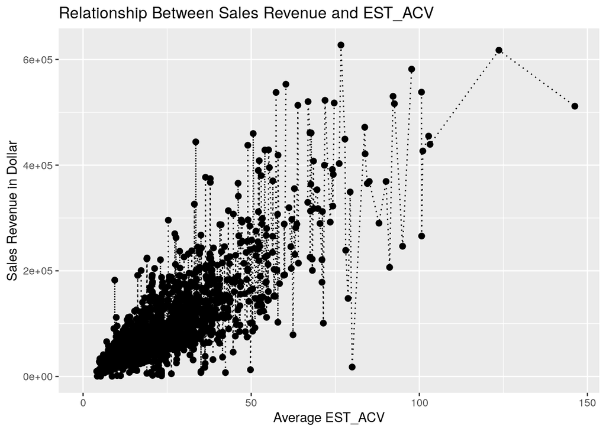

```r
ggplot(data = df6, aes(x = Average_EST_ACV, y = Revenue)) +
  geom_point(size = 2) +
  geom_line(linetype = 'dotted') +
  labs(x = 'Average EST_ACV',
       y = 'Sales Revenue in Dollar',
       title = 'Relationship Between Sales Revenue and EST_ACV')
```

We can see from the graph, on average, bigger EST_ACV implies higher overall store sales (sale revenue in dollar) as the higher EST_ACV is, the higher dollar amount sales revenue has.

What are the top 20 UPCs in terms of volume (where volume again is measured in standardized units (UNITS*VOL_EQ))?

```r
df7 <- sales %>%
    left_join(products, by = 'UPC') %>%
    mutate(vol = UNITS * VOL_EQ) %>%
    group_by(UPC) %>%
    summarise(total.vol = sum(vol)) %>%
    arrange(desc(total.vol)) %>%
    slice(1:20)

df7
```

```
## # A tibble: 20 x 2
##    UPC              total.vol
##    <chr>                <dbl>
##  1 88_2_99998_79047  2538648.
##  2 0_1_42000_44818   2459018.
##  3 0_1_54000_16447   2279243.
##  4 0_1_42000_44886   1598234.
##  5 0_1_37000_28316   1584347.
##  6 0_1_37000_28890   1566734.
##  7 0_1_37000_28876   1300595.
##  8 0_1_37000_28842   1293310.
##  9 0_1_37000_28839   1153433.
## 10 0_1_37000_21311   1111070.
## 11 0_1_30400_1380     970397.
## 12 0_1_37000_20823    835239.
## 13 0_1_37000_28831    832675.
## 14 0_1_37000_20849    783537.
## 15 0_1_30400_21473    780940.
## 16 0_1_37000_20859    750108.
## 17 0_1_37000_28873    725649.
## 18 0_1_37000_28848    665871.
## 19 0_1_37000_28850    646652.
## 20 0_1_37000_28857    619645.
```

What are the five most and five least expensive UPCs among the top 20 you found in Q7?

- Note: Here you should measure the “expensiveness” of a UPC as the **average price per standardized unit** over all weeks and stores. (Hint: The price of a UPC will change from week to week in a given store and vary between stores within a week. You should calculate the average price that was charged across all units sold of the UPC - taking into account that stores with low prices may sell more units than stores with high prices. For example, if one store sells 250 standardized units at a price of $1 per standardized unit and another store sells 100 standardized units at $1.5, then the average price charged across all units sold is NOT 0.5*$1 + 0.5*$1.5 = $1.25 since there were many more units sold at $1 than at $1.5)

```r
df8 <- sales %>%
    left_join(products, by = 'UPC') %>%
    mutate(vol = UNITS * VOL_EQ) %>%
    group_by(UPC) %>%
    summarise(Revenue = sum(DOLLARS),
              Volume = sum(vol),
              Average_Price = Revenue / Volume) %>%
    arrange(desc(Average_Price)) %>%
    slice(1:20)

head(df8, 5)
```

```
## # A tibble: 5 x 4
##   UPC              Revenue Volume Average_Price
##   <chr>              <dbl>  <dbl>         <dbl>
## 1 0_1_37000_22871   11453.   497.          23.0
## 2 0_1_83725_34500    2866.   163.          17.6
## 3 0_1_37000_16871    3854.   237.          16.2
## 4 0_1_36000_11368   45652.  3805.          12.0
## 5 88_2_99998_79809  62969.  5375.          11.7
```

```r
tail(df8, 5)
```

```
## # A tibble: 5 x 4
##   UPC             Revenue Volume Average_Price
##   <chr>             <dbl>  <dbl>         <dbl>
## 1 0_1_36000_11372 304833. 63640.          4.79
## 2 7_1_49174_9906    6632.  1397           4.75
## 3 0_1_36000_11412 308025. 65138.          4.73
## 4 0_2_36000_19244  80835. 17586.          4.60
## 5 0_1_36000_11354 349948. 76269.          4.59
```

Most marketers believe that big premium national brands use a pricing strategy called HI-LO while private label brands use a strategy called EDLP. Here HI-LO means a high price that occasionally is discounted, while EDLP means “every day low price” (a constant low price). Using the national brands BOUNTY and SCOTT and the PRIVATE LABEL brand, can you find evidence for this claim in this data? Hint: calculate the average price per brand for each week and plot this as a function of week.

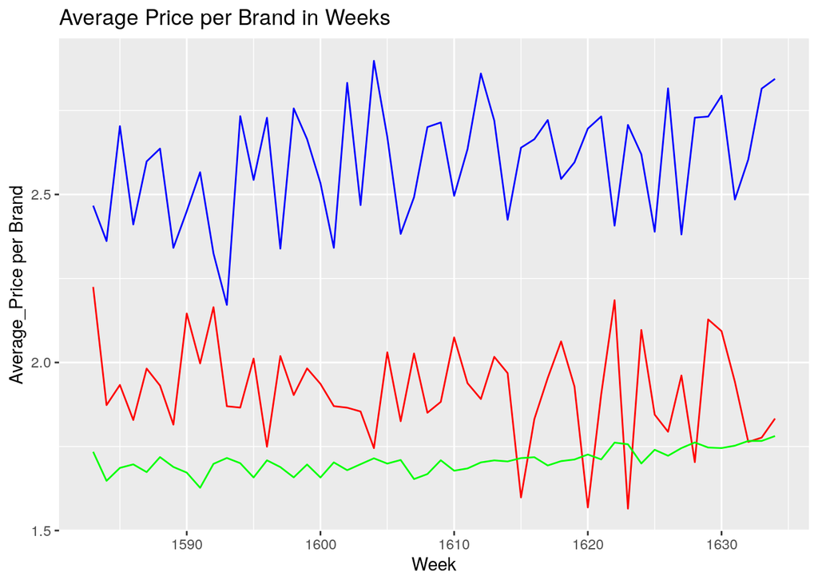

```r
df9_BOUNTY <- sales %>%
    left_join(products, by = 'UPC') %>%
    mutate(vol = UNITS * VOL_EQ) %>%
    filter(L5 == 'BOUNTY') %>%
    group_by(WEEK) %>%
    summarise(Revenue = sum(DOLLARS),
              Volume = sum(vol),
              Average_Price = Revenue / Volume) %>%
    arrange(desc(Average_Price))

df9_SCOTT <- sales %>%
    left_join(products, by = 'UPC') %>%
    mutate(vol = UNITS * VOL_EQ) %>%
    filter(L5 == 'SCOTT') %>%
    group_by(WEEK) %>%
    summarise(Revenue = sum(DOLLARS),
              Volume = sum(vol),
              Average_Price = Revenue / Volume) %>%
    arrange(desc(Average_Price))

df9_PRIVATE_LABEL <- sales %>%
    left_join(products, by = 'UPC') %>%
    mutate(vol = UNITS * VOL_EQ) %>%
    filter(L5 == 'PRIVATE LABEL') %>%
    group_by(WEEK) %>%
    summarise(Revenue = sum(DOLLARS),
              Volume = sum(vol),
              Average_Price = Revenue / Volume) %>%
    arrange(desc(Average_Price))

ggplot() +
geom_line(data = df9_BOUNTY, aes(x = WEEK, y = Average_Price), color = 'blue') +
geom_line(data = df9_SCOTT, aes(x = WEEK, y = Average_Price), color = 'red') +
geom_line(data = df9_PRIVATE_LABEL, aes(x = WEEK, y = Average_Price), color = 'green') +
    labs(x = 'Week',
       y = 'Average_Price per Brand',
       title = 'Average Price per Brand in Weeks')
```

The evidence for this claim is shown as in the graph.

Some stores close or open during the 52 week period. Create a data frame consisting of the subset of stores that were open throughout the 52 week period (remember the first week of the 52 weeks for which we have sales data is 1583 and the last is 1634) (Hint 1: the store file has information on when each store opened and closed) (Hint 2: You should get a data frame consisting of 1760 stores).

```r
stores_new <- stores %>%
   filter(between(Open, 0, 1583) & between(Clsd, 1634, 10000))

stores_new
```

```
## # A tibble: 1,760 x 7
##    IRI_KEY OU    EST_ACV Market_Name       Open  Clsd MskdName
##      <int> <chr>   <dbl> <chr>            <int> <int> <chr>
##  1  200032 GR      28.1  NEW YORK          1539  9998 Chain5
##  2  200272 GR      10.8  LOS ANGELES        873  9998 Chain110
##  3  200341 GR      26.9  SAN DIEGO         1197  9998 Chain110
##  4  200379 GR      30.2  SOUTH CAROLINA    1348  9998 Chain56
##  5  200411 GR      17.1  NEW YORK          1014  9998 Chain53
##  6  200437 GR      22.6  SAN FRANCISCO     1466  9998 Chain89
##  7  200439 GR      32.7  WEST TEX/NEW MEX   920  1655 Chain95
##  8  200485 GR       6.52 OKLAHOMA CITY      490  9998 Chain87
##  9  200488 GR      31.6  BOSTON            1329  9998 Chain92
## 10  200489 GR      19.2  HOUSTON            701  9998 Chain25
## # … with 1,750 more rows
```

Let’s investigate how prices vary by market. Each store (IRI_KEY) can be matched to a market (Market_Name) in the stores file. We will focus on the two brands BOUNTY and SCOTT and one the stores that were open in all 52 weeks (what you found in Q10). Calculate the average brand price for BOUNTY and SCOTT in each of the 50 markets. Are markets where BOUNTY is expensive also markets where SCOTT is expensive?

```r
df11_BOUNTY <- products %>%
  left_join(sales, by = 'UPC') %>%
  mutate(vol = UNITS * VOL_EQ) %>%
  left_join(stores_new, by = 'IRI_KEY') %>%
  filter(L5 == 'BOUNTY') %>%
  group_by(Market_Name) %>%
  summarise(Revenue = sum(DOLLARS),
              Volume = sum(vol),
              Average_Price = Revenue / Volume) %>%
    arrange(desc(Average_Price))

df11_SCOTT <- products %>%
  left_join(sales, by = 'UPC') %>%
  mutate(vol = UNITS * VOL_EQ) %>%
  left_join(stores_new, by = 'IRI_KEY') %>%
  filter(L5 == 'SCOTT') %>%
  group_by(Market_Name) %>%
  summarise(Revenue = sum(DOLLARS),
              Volume = sum(vol),
              Average_Price = Revenue / Volume) %>%
    arrange(desc(Average_Price))

df11_BOUNTY
```

```
## # A tibble: 51 x 4
##    Market_Name       Revenue  Volume Average_Price
##    <chr>               <dbl>   <dbl>         <dbl>
##  1 OKLAHOMA CITY      61944.  20420.          3.03
##  2 WEST TEX/NEW MEX  278525.  93686.          2.97
##  3 DES MOINES        209387.  70545.          2.97
##  4 TULSA,OK           20392.   7018.          2.91
##  5 OMAHA             256160.  88566.          2.89
##  6 EAU CLAIRE        108861.  37855.          2.88
##  7 NEW ORLEANS, LA   174571.  61501.          2.84
##  8 ST. LOUIS         772407. 276979.          2.79
##  9 BUFFALO/ROCHESTER 905607. 325179.          2.78
## 10 BIRMINGHAM/MONTG. 401034. 144063.          2.78
## # … with 41 more rows
```

```r
df11_SCOTT
```

```
## # A tibble: 51 x 4
##    Market_Name       Revenue Volume Average_Price
##    <chr>               <dbl>  <dbl>         <dbl>
##  1 BUFFALO/ROCHESTER  62871. 23964.          2.62
##  2 SEATTLE/TACOMA     84992. 35656.          2.38
##  3 WEST TEX/NEW MEX   32927. 14207.          2.32
##  4 SACRAMENTO         28295. 12230.          2.31
##  5 ST. LOUIS          72870. 31699.          2.30
##  6 SAN FRANCISCO      18509.  8101.          2.28
##  7 PORTLAND,OR        73848. 32554.          2.27
##  8 OMAHA              29628. 13250.          2.24
##  9 DES MOINES         17641.  7920.          2.23
## 10 SYRACUSE           61580. 28209.          2.18
## # … with 41 more rows
```

```
## geom_path: Each group consists of only one observation. Do you need to adjust
## the group aesthetic?
```

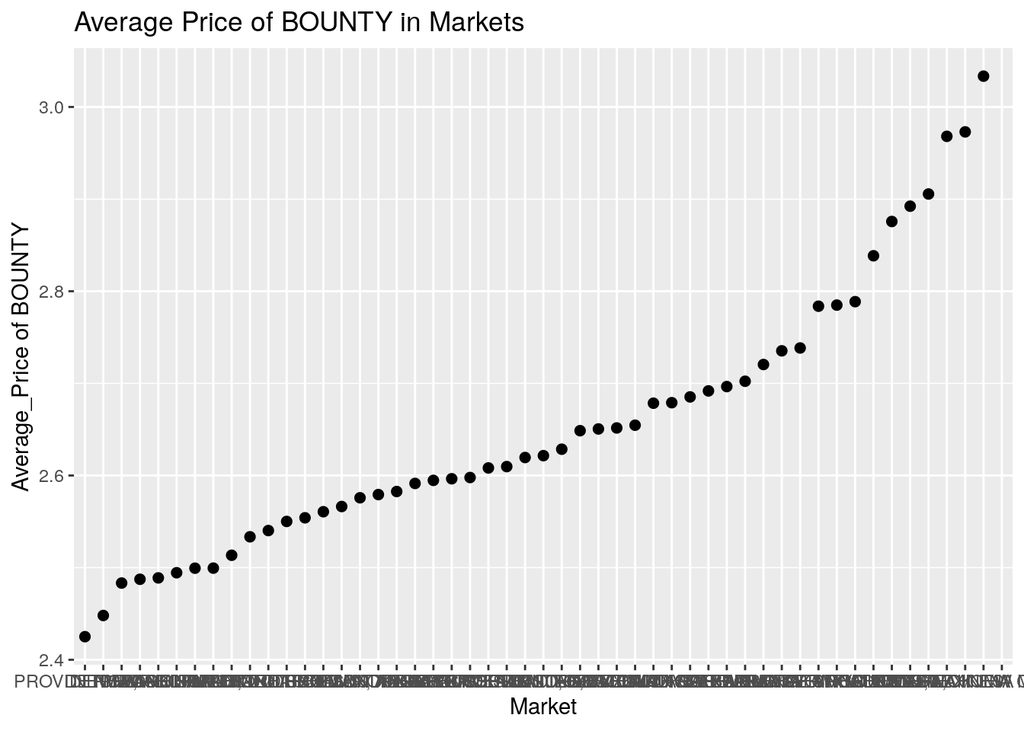

```r
ggplot(data = df11_BOUNTY, aes(x = fct_reorder(Market_Name, Average_Price), y = Average_Price)) +
  geom_point(size = 2) +
  geom_line(linetype = 'dotted') +
  labs(x = 'Market',
       y = 'Average_Price of BOUNTY',
       title = 'Average Price of BOUNTY in Markets')
```

```
## geom_path: Each group consists of only one observation. Do you need to adjust
## the group aesthetic?
```

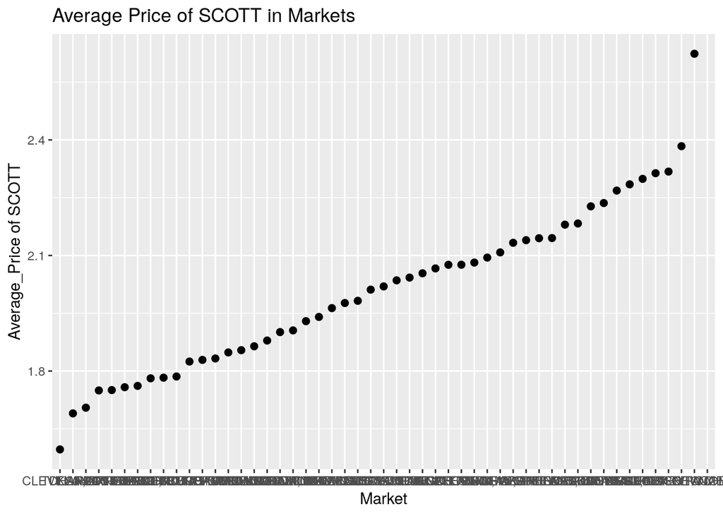

```r
ggplot(data = df11_SCOTT, aes(x = fct_reorder(Market_Name, Average_Price), y = Average_Price)) +
  geom_point(size = 2) +
  geom_line(linetype = 'dotted') +
  labs(x = 'Market',
       y = 'Average_Price of SCOTT',
       title = 'Average Price of SCOTT in Markets')
```

From the graphs, on average, average brand price of BOUNTY in markets tend to be more expensive.

UPCs vary in absorbency level, i.e., how good the product is at soaking up liquids. Do markets prefer different absorbency levels in their paper towl product? To answer this question, calculate the share of each absorbency level out of total sales for each market (where sales is measure in volume of standardized units). You can drop UPCs that have missing absorbency level for this calculation (so the share is out of all UPCs with absorbency level information). Create a visualization of absorbency level shares that highlights any potential differences in shares across markets. As above, limit your focus to stores that were open in all 52 weeks.

```r
df12 <- products %>%
  filter(!`ABSORBENCY LEVEL` == 'MISSING') %>%
  left_join(sales, by = 'UPC') %>%
  mutate(vol = UNITS * VOL_EQ) %>%
  left_join(stores_new, by = 'IRI_KEY') %>%
  group_by(Market_Name, `ABSORBENCY LEVEL`) %>%
  summarise(Volume = sum(vol),
            num = n(),
            Share = num / Volume)

df12
```

```
## # A tibble: 285 x 5
## # Groups:   Market_Name [51]
##    Market_Name       `ABSORBENCY LEVEL`    Volume   num  Share
##    <chr>             <chr>                  <dbl> <int>  <dbl>
##  1 ATLANTA           ABSORBANT            101717.  2695 0.0265
##  2 ATLANTA           CLOTHLIKE ABSORBENCY  13888.   922 0.0664
##  3 ATLANTA           MORE ABSORBANT        27872.   658 0.0236
##  4 ATLANTA           SUPER ABSORBANT       97095.  1793 0.0185
##  5 BIRMINGHAM/MONTG. ABSORBANT             69159.  3362 0.0486
##  6 BIRMINGHAM/MONTG. CLOTHLIKE ABSORBENCY  10294.   710 0.0690
##  7 BIRMINGHAM/MONTG. MORE ABSORBANT        15554.   503 0.0323
##  8 BIRMINGHAM/MONTG. SUPER ABSORBANT       37687.   991 0.0263
##  9 BOSTON            ABSORBANT            570923. 13705 0.0240
## 10 BOSTON            CLOTHLIKE ABSORBENCY  28722.  2078 0.0723
## # … with 275 more rows
```

[output not shown]

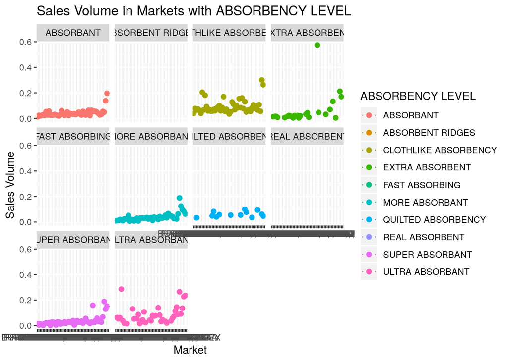

```r
ggplot(data = df12, aes(x = fct_reorder(Market_Name, Share), y = Share, color = `ABSORBENCY LEVEL`)) +
  geom_point(size = 2) +
  geom_line(linetype = 'dotted') +
  labs(x = 'Market',
       y = 'Sales Volume',
       title = 'Sales Volume in Markets with ABSORBENCY LEVEL') +
  facet_wrap(~ `ABSORBENCY LEVEL`)
```

Marketers are often interested in “market structure”, i.e., which brands compete with which other brands. In this part you are asked to investigate the market structure in the paper towel category. Focus attention only on the brands BOUNTY, SCOTT and PRIVATE LABEL. Then develop a sales model for each brand at the (Market_Name,WEEK) level. This model should predict sales of a brand in a given week and market. So to develop your model you should first aggregate the data up to this level and then generate any other variables that you think might impact demand for a certain brand.

Start by calculating sales and prices at the (market,week) level for the three brands. So for each (market,week,brand) combination you should calculate total sales volume (in standardized units as above) and the average price (as you did above).

```r
df13_BOUNTY <- products %>%
  left_join(sales, by = 'UPC') %>%
  mutate(vol = UNITS * VOL_EQ) %>%
  left_join(stores_new, by = 'IRI_KEY') %>%
  filter(L5 == 'BOUNTY') %>%
  group_by(Market_Name, WEEK) %>%
  summarise(Revenue = sum(DOLLARS),
              Volume = sum(vol),
              Average_Price = Revenue / Volume) %>%
    arrange(desc(Average_Price))

df13_SCOTT <- products %>%
  left_join(sales, by = 'UPC') %>%
  mutate(vol = UNITS * VOL_EQ) %>%
  left_join(stores_new, by = 'IRI_KEY') %>%
  filter(L5 == 'SCOTT') %>%
  group_by(Market_Name, WEEK) %>%
  summarise(Revenue = sum(DOLLARS),
              Volume = sum(vol),
              Average_Price = Revenue / Volume) %>%
    arrange(desc(Average_Price))

df13_PRIVATE_LABEL <- products %>%
  left_join(sales, by = 'UPC') %>%
  mutate(vol = UNITS * VOL_EQ) %>%
  left_join(stores_new, by = 'IRI_KEY') %>%
  filter(L5 == 'PRIVATE LABEL') %>%
  group_by(Market_Name, WEEK) %>%
  summarise(Revenue = sum(DOLLARS),
              Volume = sum(vol),
              Average_Price = Revenue / Volume) %>%
    arrange(desc(Average_Price))

df13_BOUNTY
```

```
## # A tibble: 2,653 x 5
## # Groups:   Market_Name [51]
##    Market_Name       WEEK Revenue Volume Average_Price
##    <chr>            <int>   <dbl>  <dbl>         <dbl>
##  1 TULSA,OK          1609    246.   67.7          3.63
##  2 SALT LAKE CITY    1603   1982.  557.           3.56
##  3 TULSA,OK          1589    155.   43.8          3.54
##  4 SALT LAKE CITY    1632   2259.  640.           3.53
##  5 WEST TEX/NEW MEX  1631   4417. 1261.           3.50
##  6 WEST TEX/NEW MEX  1601   3980. 1143.           3.48
##  7 WEST TEX/NEW MEX  1630   5411. 1560.           3.47
##  8 NEW ORLEANS, LA   1634   3187.  926.           3.44
##  9 WEST TEX/NEW MEX  1600   4484. 1304.           3.44
## 10 OKLAHOMA CITY     1608    584.  170.           3.44
## # … with 2,643 more rows
```

```r
df13_SCOTT
```

```
## # A tibble: 2,584 x 5
## # Groups:   Market_Name [51]
##    Market_Name    WEEK Revenue Volume Average_Price
##    <chr>         <int>   <dbl>  <dbl>         <dbl>
##  1 GRAND RAPIDS   1631    88.0   21.0          4.19
##  2 GRAND RAPIDS   1629   126.    30.1          4.19
##  3 GRAND RAPIDS   1632   104.    25.0          4.18
##  4 GRAND RAPIDS   1628   130.    31.2          4.17
##  5 GRAND RAPIDS   1630   144.    34.6          4.15
##  6 GRAND RAPIDS   1633    87.1   21.0          4.14
##  7 GRAND RAPIDS   1634   115.    27.8          4.12
##  8 SPOKANE        1622    98.4   27.8          3.53
##  9 SAN FRANCISCO  1610   174.    50.1          3.47
## 10 SPOKANE        1621    64.0   18.7          3.42
## # … with 2,574 more rows
```

```r
df13_PRIVATE_LABEL
```

```
## # A tibble: 2,653 x 5
## # Groups:   Market_Name [51]
##    Market_Name           WEEK Revenue Volume Average_Price
##    <chr>                <int>   <dbl>  <dbl>         <dbl>
##  1 MINNEAPOLIS/ST. PAUL  1632   7529.  3294.          2.29
##  2 MILWAUKEE             1614   4509.  1978.          2.28
##  3 NEW ORLEANS, LA       1594    983.   432.          2.28
##  4 NEW ORLEANS, LA       1611   1466.   644.          2.28
##  5 NEW ORLEANS, LA       1612   2029.   898.          2.26
##  6 NEW ORLEANS, LA       1593   2099.   931.          2.25
##  7 NEW ORLEANS, LA       1610   2289.  1020.          2.24
##  8 NEW ORLEANS, LA       1613   2408.  1083.          2.22
##  9 MILWAUKEE             1629   4181.  1884.          2.22
## 10 MILWAUKEE             1628   3972.  1796.          2.21
## # … with 2,643 more rows
```

Set-up three predictive models where you predict the sales volume (or log(sales volume)) of each of the three brands (in each week and market) using a set of features that you think might predict sales volume. Note that if you include the price (or log(price)) of each of the three brands as features, then you can see how the price of other brands impact sales of a given brand. This will tell you which brands compete with each other (hint: just use a linear model where you use log prices, market and week. Then look at the estimated weights for log price. You do not need to divide the data into training and validation - just train the model on the full sample).

```r
## Model: log prices, market and week
lm.BOUNTY <- lm(Volume ~ log(Average_Price) + Market_Name + WEEK, data = df13_BOUNTY)
lm.SCOTT <- lm(Volume ~ log(Average_Price) + Market_Name + WEEK, data = df13_SCOTT)
lm.PRIVATE_LABEL <- lm(Volume ~ log(Average_Price) + Market_Name + WEEK, data = df13_PRIVATE_LABEL)

summary(lm.BOUNTY)
```

```
##
## Call:
## lm(formula = Volume ~ log(Average_Price) + Market_Name + WEEK,
##     data = df13_BOUNTY)
##
## Residuals:
##    Min     1Q Median     3Q    Max
## -41157  -1531     -5   1459 107865
##
## Coefficients:
##                                   Estimate Std. Error t value Pr(>|t|)
## (Intercept)                     -10673.607  12918.838  -0.826 0.408765
## log(Average_Price)              -28477.580   1175.555 -24.225  < 2e-16 ***
## Market_NameBIRMINGHAM/MONTG.     -3702.716   1197.432  -3.092 0.002008 **
## Market_NameBOSTON                21166.824   1198.573  17.660  < 2e-16 ***
## Market_NameBUFFALO/ROCHESTER      -763.222   1197.167  -0.638 0.523841
## Market_NameCHARLOTTE             -1573.690   1199.092  -1.312 0.189503
## Market_NameCHICAGO                5559.616   1203.631   4.619 4.05e-06 ***
## Market_NameCLEVELAND             -4790.724   1197.269  -4.001 6.48e-05 ***
## Market_NameDALLAS, TX            -2145.959   1198.502  -1.791 0.073487 .
## Market_NameDES MOINES            -4017.291   1199.250  -3.350 0.000820 ***
## Market_NameDETROIT                 181.951   1204.629   0.151 0.879953
## Market_NameEAU CLAIRE            -5038.387   1198.404  -4.204 2.71e-05 ***
## Market_NameGRAND RAPIDS          -6005.240   1202.364  -4.995 6.30e-07 ***
## Market_NameGREEN BAY             -6086.338   1197.263  -5.084 3.97e-07 ***
## Market_NameHARRISBURG/SCRANT      3807.075   1199.609   3.174 0.001524 **
## Market_NameHARTFORD               4174.283   1199.294   3.481 0.000509 ***
## Market_NameHOUSTON                1003.794   1198.537   0.838 0.402381
## Market_NameINDIANAPOLIS          -4529.706   1199.565  -3.776 0.000163 ***
## Market_NameKANSAS CITY           -3505.351   1197.452  -2.927 0.003449 **
## Market_NameKNOXVILLE             -4858.347   1197.447  -4.057 5.11e-05 ***
## Market_NameLOS ANGELES            7592.332   1200.031   6.327 2.95e-10 ***
## Market_NameMILWAUKEE             -5503.144   1197.195  -4.597 4.50e-06 ***
## Market_NameMINNEAPOLIS/ST. PAUL  -5239.742   1198.386  -4.372 1.28e-05 ***
## Market_NameMISSISSIPPI           -5071.730   1197.167  -4.236 2.35e-05 ***
## Market_NameNEW ENGLAND            8396.500   1198.007   7.009 3.07e-12 ***
## Market_NameNEW ORLEANS, LA       -4381.779   1198.812  -3.655 0.000262 ***
## Market_NameNEW YORK              77477.256   1200.594  64.532  < 2e-16 ***
## Market_NameOKLAHOMA CITY         -4007.893   1202.288  -3.334 0.000870 ***
## Market_NameOMAHA                 -4123.826   1198.292  -3.441 0.000588 ***
```

[output cut: 15 more lines]

```
## Market_NameSPOKANE               -7870.375   1198.461  -6.567 6.20e-11 ***
## Market_NameST. LOUIS             -1736.204   1197.164  -1.450 0.147108
## Market_NameSYRACUSE              -2366.270   1200.251  -1.971 0.048777 *
## Market_NameTOLEDO                -5872.940   1200.102  -4.894 1.05e-06 ***
## Market_NameTULSA,OK              -5170.659   1199.419  -4.311 1.69e-05 ***
## Market_NameWASHINGTON, DC        12225.449   1202.091  10.170  < 2e-16 ***
## Market_NameWEST TEX/NEW MEX      -2596.518   1202.297  -2.160 0.030894 *
## WEEK                                29.323      8.122   3.610 0.000312 ***
## ---
## Signif. codes:  0 '***' 0.001 '**' 0.01 '*' 0.05 '.' 0.1 ' ' 1
##
## Residual standard error: 6104 on 2548 degrees of freedom
##   (53 observations deleted due to missingness)
## Multiple R-squared:  0.8274, Adjusted R-squared:  0.8239
## F-statistic: 239.5 on 51 and 2548 DF,  p-value: < 2.2e-16
```

```r
summary(lm.SCOTT)
```

```
##
## Call:
## lm(formula = Volume ~ log(Average_Price) + Market_Name + WEEK,
##     data = df13_SCOTT)
##
## Residuals:
##    Min     1Q Median     3Q    Max
## -13583   -455    -42    356  38659
##
## Coefficients:
##                                  Estimate Std. Error t value Pr(>|t|)
## (Intercept)                     -4575.781   4773.755  -0.959  0.33789
## log(Average_Price)              -5706.310    314.321 -18.154  < 2e-16 ***
## Market_NameBIRMINGHAM/MONTG.     -501.784    437.500  -1.147  0.25152
## Market_NameBOSTON                1788.285    440.127   4.063 4.99e-05 ***
## Market_NameBUFFALO/ROCHESTER      815.357    442.250   1.844  0.06535 .
## Market_NameCHARLOTTE              216.505    439.741   0.492  0.62252
## Market_NameCHICAGO               1853.369    438.423   4.227 2.45e-05 ***
## Market_NameCLEVELAND            -2349.648    448.804  -5.235 1.78e-07 ***
## Market_NameDALLAS, TX             -62.601    437.382  -0.143  0.88620
## Market_NameDES MOINES            -716.243    437.386  -1.638  0.10164
## Market_NameDETROIT               -484.823    438.385  -1.106  0.26886
## Market_NameEAU CLAIRE            -668.292    437.393  -1.528  0.12667
## Market_NameGRAND RAPIDS          -328.134    437.770  -0.750  0.45359
## Market_NameGREEN BAY             -894.570    437.456  -2.045  0.04097 *
## Market_NameHARRISBURG/SCRANT     -105.965    440.997  -0.240  0.81013
## Market_NameHARTFORD               987.911    440.226   2.244  0.02491 *
## Market_NameHOUSTON                546.524    437.593   1.249  0.21181
## Market_NameINDIANAPOLIS          -258.025    437.408  -0.590  0.55531
## Market_NameKANSAS CITY          -1327.884    440.474  -3.015  0.00260 **
## Market_NameKNOXVILLE             -754.091    438.742  -1.719  0.08578 .
## Market_NameLOS ANGELES           1320.906    437.601   3.019  0.00257 **
## Market_NameMILWAUKEE             -600.955    437.391  -1.374  0.16958
## Market_NameMINNEAPOLIS/ST. PAUL  -968.498    439.014  -2.206  0.02747 *
## Market_NameMISSISSIPPI           -553.391    437.489  -1.265  0.20602
## Market_NameNEW ENGLAND           -100.185    438.265  -0.229  0.81920
## Market_NameNEW ORLEANS, LA       -410.181    437.518  -0.938  0.34858
## Market_NameNEW YORK             17328.229    441.675  39.233  < 2e-16 ***
## Market_NameOKLAHOMA CITY        -1345.408    512.270  -2.626  0.00868 **
## Market_NameOMAHA                 -441.628    437.447  -1.010  0.31281
```

[output cut: 15 more lines]

```
## Market_NameSPOKANE               -775.449    437.382  -1.773  0.07636 .
## Market_NameST. LOUIS              198.589    438.000   0.453  0.65030
## Market_NameSYRACUSE              -352.733    437.395  -0.806  0.42007
## Market_NameTOLEDO                -647.094    437.571  -1.479  0.13931
## Market_NameTULSA,OK             -2746.355   1051.322  -2.612  0.00905 **
## Market_NameWASHINGTON, DC        1306.774    438.498   2.980  0.00291 **
## Market_NameWEST TEX/NEW MEX       267.634    439.753   0.609  0.54284
## WEEK                                6.246      2.971   2.102  0.03562 *
## ---
## Signif. codes:  0 '***' 0.001 '**' 0.01 '*' 0.05 '.' 0.1 ' ' 1
##
## Residual standard error: 2230 on 2479 degrees of freedom
##   (53 observations deleted due to missingness)
## Multiple R-squared:  0.6541, Adjusted R-squared:  0.647
## F-statistic: 91.91 on 51 and 2479 DF,  p-value: < 2.2e-16
```

```r
summary(lm.PRIVATE_LABEL)
```

```
##
## Call:
## lm(formula = Volume ~ log(Average_Price) + Market_Name + WEEK,
##     data = df13_PRIVATE_LABEL)
##
## Residuals:
##     Min      1Q  Median      3Q     Max
## -6933.7  -562.5   -16.0   483.9 10008.8
##
## Coefficients:
##                                  Estimate Std. Error t value Pr(>|t|)
## (Intercept)                       1801.34    2656.73   0.678 0.497816
## log(Average_Price)              -10949.80     415.32 -26.365  < 2e-16 ***
## Market_NameBIRMINGHAM/MONTG.     -5175.85     246.56 -20.992  < 2e-16 ***
## Market_NameBOSTON                21835.90     245.30  89.016  < 2e-16 ***
## Market_NameBUFFALO/ROCHESTER     13561.21     247.64  54.761  < 2e-16 ***
## Market_NameCHARLOTTE             -3224.28     248.27 -12.987  < 2e-16 ***
## Market_NameCHICAGO                7084.74     250.81  28.247  < 2e-16 ***
## Market_NameCLEVELAND             -7058.51     247.62 -28.505  < 2e-16 ***
## Market_NameDALLAS, TX             1754.79     247.54   7.089 1.74e-12 ***
## Market_NameDES MOINES            -6535.40     250.15 -26.126  < 2e-16 ***
## Market_NameDETROIT                3649.05     247.52  14.742  < 2e-16 ***
## Market_NameEAU CLAIRE            -7327.15     249.49 -29.368  < 2e-16 ***
## Market_NameGRAND RAPIDS          -3853.80     249.38 -15.454  < 2e-16 ***
## Market_NameGREEN BAY             -7139.73     252.12 -28.318  < 2e-16 ***
## Market_NameHARRISBURG/SCRANT      1687.60     247.55   6.817 1.15e-11 ***
## Market_NameHARTFORD              -1416.69     245.83  -5.763 9.26e-09 ***
## Market_NameHOUSTON                2160.05     245.22   8.808  < 2e-16 ***
## Market_NameINDIANAPOLIS          -3939.67     248.44 -15.858  < 2e-16 ***
## Market_NameKANSAS CITY           -3200.74     245.24 -13.051  < 2e-16 ***
## Market_NameKNOXVILLE             -3868.36     248.25 -15.582  < 2e-16 ***
## Market_NameLOS ANGELES           22948.54     247.95  92.552  < 2e-16 ***
## Market_NameMILWAUKEE             -5339.41     256.43 -20.822  < 2e-16 ***
## Market_NameMINNEAPOLIS/ST. PAUL  -4905.13     253.42 -19.355  < 2e-16 ***
## Market_NameMISSISSIPPI           -5434.32     245.59 -22.127  < 2e-16 ***
## Market_NameNEW ENGLAND            9407.33     245.30  38.351  < 2e-16 ***
## Market_NameNEW ORLEANS, LA       -6504.26     257.80 -25.230  < 2e-16 ***
## Market_NameNEW YORK              19528.60     245.51  79.543  < 2e-16 ***
## Market_NameOKLAHOMA CITY         -9048.31     245.32 -36.884  < 2e-16 ***
## Market_NameOMAHA                 -6099.51     247.58 -24.637  < 2e-16 ***
```

[output cut: 15 more lines]

```
## Market_NameSPOKANE               -6438.93     253.11 -25.439  < 2e-16 ***
## Market_NameST. LOUIS             -2951.79     248.71 -11.868  < 2e-16 ***
## Market_NameSYRACUSE               5212.23     249.24  20.913  < 2e-16 ***
## Market_NameTOLEDO                -4298.80     248.44 -17.303  < 2e-16 ***
## Market_NameTULSA,OK             -10117.52     246.58 -41.032  < 2e-16 ***
## Market_NameWASHINGTON, DC         5185.19     245.36  21.133  < 2e-16 ***
## Market_NameWEST TEX/NEW MEX      -4728.93     251.84 -18.778  < 2e-16 ***
## WEEK                                 8.26       1.67   4.947 8.02e-07 ***
## ---
## Signif. codes:  0 '***' 0.001 '**' 0.01 '*' 0.05 '.' 0.1 ' ' 1
##
## Residual standard error: 1250 on 2548 degrees of freedom
##   (53 observations deleted due to missingness)
## Multiple R-squared:  0.975,  Adjusted R-squared:  0.9745
## F-statistic:  1949 on 51 and 2548 DF,  p-value: < 2.2e-16
```

```r
## show coefficients
effects_BOUNTY <- select(tidy(lm.BOUNTY),term,estimate)
effects_SCOTT <- select(tidy(lm.SCOTT),term,estimate)
effects_PRIVATE_LABEL <- select(tidy(lm.PRIVATE_LABEL),term,estimate)

effects_BOUNTY
```

```
## # A tibble: 52 x 2
##    term                         estimate
##    <chr>                           <dbl>
##  1 (Intercept)                   -10674.
##  2 log(Average_Price)            -28478.
##  3 Market_NameBIRMINGHAM/MONTG.   -3703.
##  4 Market_NameBOSTON              21167.
##  5 Market_NameBUFFALO/ROCHESTER    -763.
##  6 Market_NameCHARLOTTE           -1574.
##  7 Market_NameCHICAGO              5560.
##  8 Market_NameCLEVELAND           -4791.
##  9 Market_NameDALLAS, TX          -2146.
## 10 Market_NameDES MOINES          -4017.
## # … with 42 more rows
```

```r
effects_SCOTT
```

```
## # A tibble: 52 x 2
##    term                         estimate
##    <chr>                           <dbl>
##  1 (Intercept)                   -4576.
##  2 log(Average_Price)            -5706.
##  3 Market_NameBIRMINGHAM/MONTG.   -502.
##  4 Market_NameBOSTON              1788.
##  5 Market_NameBUFFALO/ROCHESTER    815.
##  6 Market_NameCHARLOTTE            217.
##  7 Market_NameCHICAGO             1853.
##  8 Market_NameCLEVELAND          -2350.
##  9 Market_NameDALLAS, TX           -62.6
## 10 Market_NameDES MOINES          -716.
## # … with 42 more rows
```

```r
effects_PRIVATE_LABEL
```

```
## # A tibble: 52 x 2
##    term                         estimate
##    <chr>                           <dbl>
##  1 (Intercept)                     1801.
##  2 log(Average_Price)            -10950.
##  3 Market_NameBIRMINGHAM/MONTG.   -5176.
##  4 Market_NameBOSTON              21836.
##  5 Market_NameBUFFALO/ROCHESTER   13561.
##  6 Market_NameCHARLOTTE           -3224.
##  7 Market_NameCHICAGO              7085.
##  8 Market_NameCLEVELAND           -7059.
##  9 Market_NameDALLAS, TX           1755.
## 10 Market_NameDES MOINES          -6535.
## # … with 42 more rows
```